# Ch2. 라이브러리-Numpy

## 1. 라이브러리란..

- 라이브러리(library)란 대상환경에서 바로 실행될수있도록 모듈화된 프로그램입니다.
- 고수들이 만들어놓은 함수모음집이라고 생각하면됩니다.

## 2. 대표적인 라이브러리들

- 내장라이브러리
  - time
  - random
- 외부라이브러리
  - [Numpy](https://numpy.org/)
  - [Matplotlib](https://matplotlib.org/)
  - [Scipy](https://scipy.org/)
  - [pandas](https://pandas.pydata.org/)
  - [CoolProp](https://coolprop.org/)

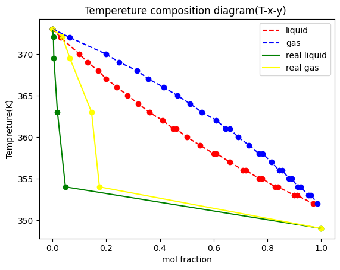

numpy,matplotlib,coolprop를 활용했습니다.

## 3. 라이브러리 사용법

pip install “라이브러리 이름”

- 대부분 이런식으로 다운로드받고 사용합니다.
- 방법은 라이브러리 홈페이지에 나와있습니다.
- Colab에는 Numpy, Matplotlib 등등이 다운로드되어있으므로 바로 사용할수 있습니다.

## 4. 라이브러리 선언

- 라이브러리를 사용하기 위해 선언을해줘야합니다.

```python
#| echo: True
#| output: False
#| warning: False

import "라이브러리" as "축약형"
import numpy as np
import matplotlib.pyplot as plt
import pandas as pd
```

- import 로 선언하고 as로 부르기쉽게 축약합니다.
- 관례적으로 Numpy 는 np로, matplotlib는 plt로 줄여씁니다.
- 다른사람이 코드를 이해하기 쉽도록 관례를 따라줍시다.

## Numpy

- 오늘은 [numpy](https://numpy.org/)에 대해 알아봅시다.

**“The fundamental package for scientific computing with Python”** 라고합니다.

## 기초

```python
import numpy as np


a=np.array([0,1,2,3])
print(a,type(a))

print(np.arange(10))
```

```
[0 1 2 3] <class 'numpy.ndarray'>
[0 1 2 3 4 5 6 7 8 9]
```

- np.array([]) 로 ndarray라는 자료를 생성하여 연산합니다.
- np.arange() 로 범위만큼 생성할수도있습니다.

```python
def types(x):
    print(x,type(x),np.shape(x),np.size(x))

a=np.zeros(10)
types(a)
b=np.zeros((5,3))
types(b)
c=np.zeros((5,3),dtype=int)
types(c)
```

```
[0. 0. 0. 0. 0. 0. 0. 0. 0. 0.] <class 'numpy.ndarray'> (10,) 10
[[0. 0. 0.]
 [0. 0. 0.]
 [0. 0. 0.]
 [0. 0. 0.]
 [0. 0. 0.]] <class 'numpy.ndarray'> (5, 3) 15
[[0 0 0]
 [0 0 0]
 [0 0 0]
 [0 0 0]
 [0 0 0]] <class 'numpy.ndarray'> (5, 3) 15
```

- np.zeros()로 0으로채워진 ndarray를 생성할수있습니다.
- np.shape()로 모양(몇개의 행,몇개의 열), np.size()로 원소의 개수를 알수있습니다.
- 0뒤에있는 ‘.’ 은 실수형이라는 표시입니다. 정수보다 실수가 안정해서 기본적으로 실수형으로 출력합니다.

## 기본적인 구조

- 우리가 Python으로 풀고싶은문제는 행렬을 사용할때가 많습니다.
- Python에서 어떻게 행렬을 인식하는지 알아봅시다.

```
[['*' '열' '열' '열']
 ['행' 1 2 3]
 ['행' 4 5 6]
 ['행' 7 8 9]]
```

```python
import numpy as np

a=np.zeros((3,5),dtype=int)

for i in range(3):
 for j in range(5):
  a[i][j]=5*i+j+1
print(a)

b=np.arange(1,16).reshape(3,5)
print(b)

print('0행3열',b[0][3])
```

```
[[ 1  2  3  4  5]
 [ 6  7  8  9 10]
 [11 12 13 14 15]]
[[ 1  2  3  4  5]
 [ 6  7  8  9 10]
 [11 12 13 14 15]]
0행3열 4
```

- np.reshape로 행렬을 원하는 모양으로 바꿀수있습니다.

## linspace

- np.linspace를 통해 내가 원하는 만큼 구간을 잘게 쪼갤수 있습니다.

```python
print(np.linspace(0,10,2,dtype=int))
print(np.linspace(0,10,6,dtype=int))
print(np.linspace(0,10,10,dtype=int))
```

```
[ 0 10]
[ 0  2  4  6  8 10]
[ 0  1  2  3  4  5  6  7  8 10]
```

- np.linspace(범위, 조각수) 로 사용합니다.
- 시각화 할때 자주 쓰입니다.

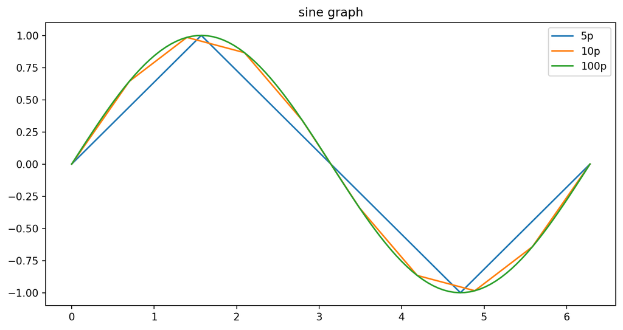

## 마치며..

- 스스로 학습하며..